# HARDOUIN_OPTIMIZATION slides

### Executive Master Dauphine “Optimization for Machine Learning”

#### Paul HARDOUIN Le 10 juillet 2020

#### PLAN

- 1. Régression
  - 1.1. Dataset 1 : Ground State Energies of 16,242 Molecules
  - 1.2. Comparaison Descente de Gradient - Ridge - Lasso
    - 1.2.1 Descente de gradient classique
    - 1.2.2 Régularisation RIDGE
    - 1.2.3 Descente de gradient avec régularisation LASSO
- 2. Classification
  - 2.1. Dataset 2 : Diamonds
  - 2.2. Two Classes Logistic Classification
    - 2.2.1 Batch Gradient Descent (BGD)
    - 2.2.2 Stochastic Gradient Descent (SGD)
    - 2.2.3 Comparaison des performances
  - 2.3. Multi-Classes Logistic Classification

## 1. Régression back to plan

### 1.1. Dataset 1 : Ground State Energies of 16,242 Molecules back to plan

En premier lieu, nous chargeons les librairies nécéssaires pour cette étude.

```python
%matplotlib inline
import numpy as np
import pandas as pd
import matplotlib.pyplot as plt
import kaggle as kg
import seaborn as sns
%load_ext autoreload
%autoreload 2
```

Dans cette étude, nous allons travailler avec le dataset **Ground State Energies of 16,242 Molecules** de Kaggle. Nous voulons déterminer l'énergie atomique d'une molécule à partir de 1275 valeurs caractéristiques moléculaires. De tels calculs peuvent se faire par simulations, mais sont très couteux. On envisage donc de construire un modèle de détermination par machine learning.

```python
kg.api.authenticate()
kg.api.dataset_download_files(dataset="burakhmmtgl/energy-molecule", path='gt.zip', unzip=True)
```

```python
df = pd.read_csv('gt.zip/roboBohr.csv', encoding='ISO-8859-1')
df.head(3)
```

|  | Unnamed: 0 | 0 | 1 | 2 | 3 | 4 | 5 | 6 | 7 | 8 | ... | 1267 | 1268 | 1269 | 1270 | 1271 | 1272 | 1273 | 1274 | pubchem_id | Eat |
| --- | --- | --- | --- | --- | --- | --- | --- | --- | --- | --- | --- | --- | --- | --- | --- | --- | --- | --- | --- | --- | --- |
| 0 | 0 | 73.516695 | 17.817765 | 12.469551 | 12.458130 | 12.454607 | 12.447345 | 12.433065 | 12.426926 | 12.387474 | ... | 0.0 | 0.0 | 0.5 | 0.0 | 0.0 | 0.0 | 0.0 | 0.0 | 25004 | -19.013763 |
| 1 | 1 | 73.516695 | 20.649126 | 18.527789 | 17.891535 | 17.887995 | 17.871731 | 17.852586 | 17.729842 | 15.864270 | ... | 0.0 | 0.0 | 0.0 | 0.0 | 0.0 | 0.0 | 0.0 | 0.0 | 25005 | -10.161019 |
| 2 | 2 | 73.516695 | 17.830377 | 12.512263 | 12.404775 | 12.394493 | 12.391564 | 12.324461 | 12.238106 | 10.423249 | ... | 0.0 | 0.0 | 0.0 | 0.0 | 0.0 | 0.0 | 0.0 | 0.0 | 25006 | -9.376619 |

3 rows × 1278 columns

```python
df.describe()
```

|  | Unnamed: 0 | 0 | 1 | 2 | 3 | 4 | 5 | 6 | 7 | 8 | ... | 1267 | 1268 | 1269 | 1270 | 1271 | 1272 | 1273 | 1274 | pubchem_id | Eat |
| --- | --- | --- | --- | --- | --- | --- | --- | --- | --- | --- | --- | --- | --- | --- | --- | --- | --- | --- | --- | --- | --- |
| count | 16242.000000 | 16242.000000 | 16242.000000 | 16242.000000 | 16242.000000 | 16242.000000 | 16242.000000 | 16242.000000 | 16242.000000 | 16242.000000 | ... | 16242.000000 | 16242.000000 | 16242.000000 | 16242.000000 | 16242.000000 | 16242.000000 | 16242.000000 | 16242.000000 | 16242.000000 | 16242.000000 |
| mean | 8139.041805 | 115.715266 | 22.445723 | 20.474191 | 18.529573 | 17.169350 | 15.816888 | 15.133152 | 14.471534 | 13.960759 | ... | 0.000134 | 0.000133 | 0.003879 | 0.000131 | 0.000129 | 0.002155 | 0.000127 | 0.001201 | 33107.484300 | -11.178969 |
| std | 4698.182820 | 113.198503 | 8.659586 | 7.670481 | 6.485777 | 5.512560 | 4.179691 | 3.885091 | 3.503075 | 3.357136 | ... | 0.002728 | 0.002705 | 0.043869 | 0.002676 | 0.002633 | 0.032755 | 0.002594 | 0.024472 | 23456.785147 | 3.659133 |
| min | 0.000000 | 36.858105 | 2.906146 | 0.000000 | 0.000000 | 0.000000 | 0.000000 | 0.000000 | 0.000000 | 0.000000 | ... | 0.000000 | 0.000000 | 0.000000 | 0.000000 | 0.000000 | 0.000000 | 0.000000 | 0.000000 | 1.000000 | -23.245373 |
| 25% | 4068.250000 | 73.516695 | 17.969345 | 16.228071 | 15.165862 | 13.744092 | 13.653146 | 13.637784 | 12.759519 | 12.587359 | ... | 0.000000 | 0.000000 | 0.000000 | 0.000000 | 0.000000 | 0.000000 | 0.000000 | 0.000000 | 12298.250000 | -13.475805 |
| 50% | 8142.500000 | 73.516695 | 20.662511 | 18.631287 | 17.690729 | 16.020040 | 15.156646 | 13.848274 | 13.659233 | 13.652832 | ... | 0.000000 | 0.000000 | 0.000000 | 0.000000 | 0.000000 | 0.000000 | 0.000000 | 0.000000 | 27731.500000 | -10.835211 |
| 75% | 12207.750000 | 73.516695 | 21.132432 | 20.739496 | 18.712895 | 18.297501 | 17.639688 | 16.154918 | 15.499474 | 14.900585 | ... | 0.000000 | 0.000000 | 0.000000 | 0.000000 | 0.000000 | 0.000000 | 0.000000 | 0.000000 | 55020.750000 | -8.623903 |
| max | 16272.000000 | 388.023441 | 73.563510 | 66.269180 | 66.268891 | 66.268756 | 66.268196 | 66.264158 | 66.258487 | 66.258177 | ... | 0.062225 | 0.061999 | 0.500000 | 0.061534 | 0.059760 | 0.500000 | 0.057834 | 0.500000 | 74980.000000 | -0.789513 |

8 rows × 1278 columns

```python
len(np.unique(df["pubchem_id"]))
```

```
16242
```

Il n'y a pas de données manquantes.  
Pour cette étude, on enlève la colonne **Unnamed: 0**, qui n'est qu'un index sans pertinence. On enlève aussi la colonne **pubchem_id** que nous ne traitons pas ici : elle correspond à des identités moléculaires, toutes différentes dans ce dataset, donc compliquées à utiliser pour construire un modèle statistique de classification).

```python
df = df.drop(['Unnamed: 0','pubchem_id'],axis=1)
```

**Création de jeu test/train**  
Afin d'avoir un problème relativement mal conditionné, on ne s'entraine qu'avec 10% des individus, soit 1624 individus, ce qui est du même ordre de grandeur que le nombre de features, qui vaut 1275. Cela permettra la recherche d'une solution sparse lors de la régularisation **Lasso**.

```python
# Values
#-----------------------
X = df.drop(['Eat'],axis=1).values
y = df.get(['Eat']).values.reshape(-1,1)

# Permutation
#-----------------------
np.random.seed(96)
ind = np.random.permutation(X.shape[0])
X = X[ind,:]
y = y[ind,:]

# Split 10/90
#-----------------------
[n,p] = X.shape
n0 = n*1//10
X0 = X[:n0,:]
y0 = y[:n0]
X1 = X[n0:,:]
y1 = y[n0:]
```

### 1.2. Comparaison Descente de Gradient - Ridge - Lasso back to plan

On va chercher un modèle de régression linéaire.  
On normalise les données pour cet exercice, selon les paramètres du dataset d'entrainement.

```python
mX0 = X0.mean(axis=0)
sX0 = X0.std(axis=0)
X0 = (X0-mX0)/sX0
X1 = (X1-mX0)/sX0
m0 = y0.mean()
y0 = y0-m0
y1 = y1-m0
```

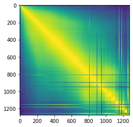

```python
C = X0.transpose().dot(X0)
plt.imshow(C);
```

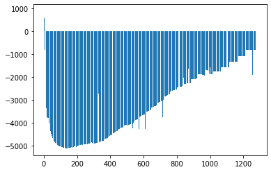

```python
u = X0.transpose().dot(y0)
plt.clf
plt.bar(np.arange(1,p+1),u.flatten())
plt.axis('tight');
```

#### 1.2.1. Descente de gradient classique back to plan

On fait une descente de gradient sans regulariastion, et on observe l'impact de la step size sur la convergence. Dans les paramètres testés, on obtient la meilleure convergence pour $\tau = 1.98\times\lVert XX^\top\lVert$, même si le meilleur compromis (vitesse, limite) semble être pour $\tau = 1.80\times\lVert XX^\top\lVert$.

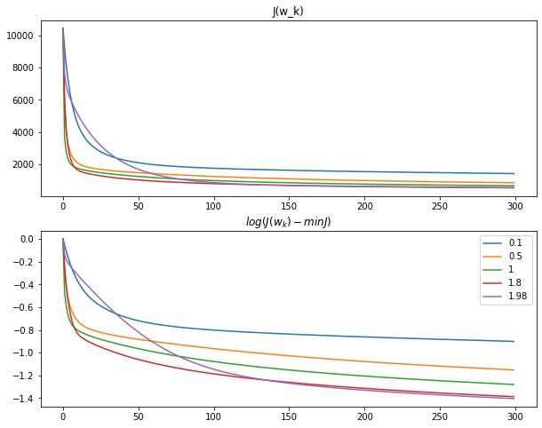

```python
# Fonctions Cout et Gradient
#-----------------------
def J(w): return 1/2*np.linalg.norm(X0.dot(w)-y0)**2
def GradJ(w): return X0.transpose().dot(X0.dot(w)-y0)

# Quelques valeurs de STEP
#-----------------------
niter = 300
Jlist = np.zeros((niter,1))
tau_mult = [.1, .5, 1, 1.8, 1.98];
wopt = np.linalg.solve( X0.transpose().dot(X0), X0.transpose().dot(y0) )
plt.clf
fig, (ax1, ax2) = plt.subplots(2, 1)
fig.set_size_inches(10,8)
for itau in np.arange(0,5):
    tau = tau_mult[itau]/np.linalg.norm(X0,2)**2
    w = np.zeros((p,1))
    for i in np.arange(0,niter):
        Jlist[i] = J(w)
        w = w - tau*GradJ(w)
    ax1.plot(Jlist)
    ax1.axis('tight')
    ax1.set_title('J(w_k)')
    e = np.log10( Jlist-J(wopt) +1e-20)
    ax2.plot(e-e[0], label=str(tau_mult[itau]))
    ax2.axis('tight')
    ax2.set_title('$log(J(w_k)-min J)$')
    leg = ax2.legend()
```

Concernant l'estimateur des moindres carrés, il semble complètement hors des clous, sans doute à cause du faible nombre d'individus par rapport au nombre de features.

```
Moindres carrés: 3821336.447856841%
```

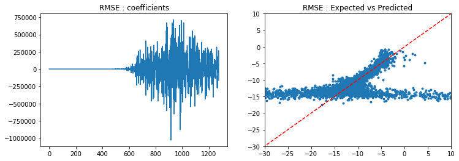

```python
plt.clf
fig, (ax1, ax2) = plt.subplots(1,2)
fig.set_size_inches(12,4)
ax1.plot(wopt)
ax1.axis('tight')
ax1.set_title('RMSE : coefficients')
ax2.plot(X1.dot(wopt)+m0,y1+m0,'.')
ax2.plot(np.arange(-100,100),np.arange(-100,100),'r--')
ax2.axis((-30,10,-30,10))
ax2.set_title('RMSE : Expected vs Predicted')
print('Moindres carrés: ' + str(100*np.linalg.norm(X1.dot(wopt)-y1) / np.linalg.norm(y1)) + '%')
```

Concernant l'estimateur par descente de gradient, son erreur semble plus raisonnable. Le modèle trouve semble plus stable.

```
Descente gradient: 26.054867092549518%
```

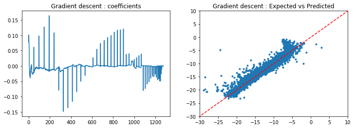

```python
plt.clf
fig, (ax1, ax2) = plt.subplots(1,2)
fig.set_size_inches(12,4)
ax1.plot(w)
ax1.axis('tight')
ax1.set_title('Gradient descent : coefficients')
ax2.plot(X1.dot(w)+m0,y1+m0,'.')
ax2.plot(np.arange(-100,100),np.arange(-100,100),'r--')
ax2.axis((-30,10,-30,10))
ax2.set_title('Gradient descent : Expected vs Predicted')
print('Descente gradient: ' + str(100*np.linalg.norm(X1.dot(w)-y1) / np.linalg.norm(y1)) + '%')
```

#### 1.2.2. Régularisation RIDGE back to plan

Comme le problème est mal conditionné, on met en place une régularisation RIDGE pour guider sa résolution vers un vecteur de coefficients ayant une énergie relativement faible. On cherche donc le paramètre optimal pour la régularisation.

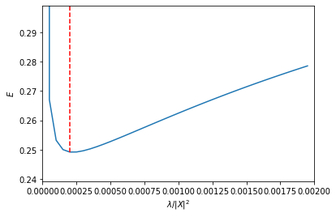

```python
# Tableau
#-----------------------
lambda_factor = np.arange(0,.002,.00005)
n = lambda_factor.size
test_error = np.zeros((n,1))
Xnorm = np.linalg.norm(X0,2)**2
## important de preciser norme 2, comme c'est une matrice (sinon, Frobenius est choisie)

# Loop
#-----------------------
for ind in np.arange(0,n):
    Lambda = lambda_factor[ind]*Xnorm;
    w = np.linalg.solve( X0.transpose().dot(X0) + Lambda*np.eye(p), X0.transpose().dot(y0) )
    #w = X0.transpose().dot(np.linalg.solve( X0.dot(X0.transpose()) + Lambda*np.eye(n0), y0 ))
    test_error[ind] = np.linalg.norm(X1.dot(w)-y1) / np.linalg.norm(y1)
l_opt = lambda_factor[test_error.argmin()]
wRidge = np.linalg.solve( X0.transpose().dot(X0) + l_opt*Xnorm*np.eye(p), X0.transpose().dot(y0) )

# Figure
#-----------------------
plt.clf
plt.figure(figsize=(6, 4))
plt.plot(lambda_factor,test_error)
plt.plot([l_opt,l_opt],[test_error.min(),test_error.max()],'r--')
plt.axis('tight')
plt.xlim([0,.002])
plt.ylim([test_error.min()-.01,test_error.min()+.05])
plt.xlabel('$\lambda/|X|^2$')
plt.ylabel('$E$');
```

```
Ridge: 24.920857463763404%
```

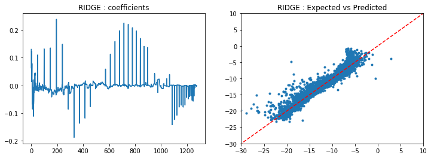

```python
plt.clf
fig, (ax1, ax2) = plt.subplots(1,2)
fig.set_size_inches(12,4)
ax1.plot(wRidge)
ax1.axis('tight')
ax1.set_title('RIDGE : coefficients')
ax2.plot(X1.dot(wRidge)+m0,y1+m0,'.')
ax2.plot(np.arange(-100,100),np.arange(-100,100),'r--')
ax2.axis((-30,10,-30,10))
ax2.set_title('RIDGE : Expected vs Predicted')
print( 'Ridge: ' + str(test_error.min()*100) + '%' )
```

On cherche à comparer ce résultat aux librairies usuelles du machine learning, à savoir le package **scikit-learn**.  
Les prédictions se superposent quasiment et les performances sont quasi-identiques (24.92% versus 25.10%).  
Cela valide notre méthode a la mano.

```
Ridge SCIKIT: 25.104514983006492%
```

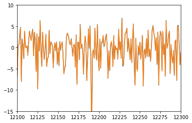

```python
# Modele Scikit-learn
#-----------------------
from sklearn.linear_model import RidgeCV
clf = RidgeCV(alphas=lambda_factor[1:]*Xnorm).fit(X0, y0)

# Affichage des 2 predictions
#-----------------------
plt.plot(X1.dot(wRidge))
plt.plot(clf.predict(X1))
plt.ylim([-15,10])
plt.xlim([12100,12300])

# Performance du modele Scikit-learn
#-----------------------
print( 'Ridge SCIKIT: ' + str(np.linalg.norm(clf.predict(X1)-y1) / np.linalg.norm(y1)*100) + '%' )
```

#### 1.2.3. Descente de gradient avec régularisation LASSO back to plan

Comme le problème est mal conditionné, on peut également essayer d'améliorer cela en sélectionnant les coefficients les plus pertinents au travers d'une recherche de solution sparse. Pour cela, on effectue une descente de gradient avec régularisation LASSO. On cherche donc le paramètre optimal pour la régularisation.

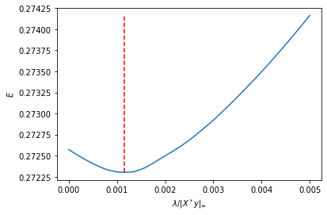

```python
# Fonction Cout + Soft-Thresholding + ISTA
#-----------------------
C = X0.transpose().dot(X0)
u = X0.transpose().dot(y0)
def J(w,Lambda): return 1/2*np.linalg.norm(X0.dot(w)-y0)**2 + Lambda*np.linalg.norm(w,1)
def Soft(x,s): return np.maximum( abs(x)-s, np.zeros(x.shape)  ) * np.sign(x)
def ISTA(w,Lambda,tau): return Soft( w-tau*( C.dot(w)-u ), Lambda*tau )

# Descente
#-----------------------
q = 101
lmax = abs( X0.transpose().dot(y0) ).max()
tau = 1.5/np.linalg.norm(X0,2)**2
lambda_list = lmax*np.linspace(.005,0,q)
W = np.zeros( (p,q) )
E = np.zeros( (q,1) )
niter = 250
for iq in np.arange(0,q):
    w = np.zeros((p,1))
    Lambda = lambda_list[iq]
    # ISTA #
    for i in np.arange(0,niter):
        w = ISTA(w,Lambda,tau)
    W[:,iq] = w.flatten() # bookkeeping
    E[iq] = np.linalg.norm(X1.dot(w)-y1) / np.linalg.norm(y1)

# Lambda optimal
#-----------------------
i = E.argmin()
lambda0 = lambda_list[i]
wSparse = W[:,i]

# Figure
#-----------------------
plt.clf
plt.plot(lambda_list/lmax, E)
plt.plot( [lambda0/lmax,lambda0/lmax], [E.min(),E.max()], 'r--')
plt.axis('tight')
plt.xlabel('$\lambda/|X^* y|_\infty$')
plt.ylabel('$E$')
```

Une fois que l'on a trouvé le bon paramètre, on refait tourner l'algorithme sur plus d'itérations, jusqu'à la limite de sur apprentissage.

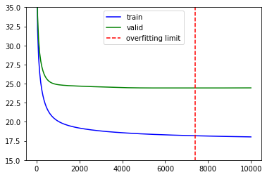

```python
# ISTA
#-----------------------
niter = 10000
sampleRate = 50
E_train = np.zeros( (1+niter//sampleRate,1) )
E_valid = np.zeros( (1+niter//sampleRate,1) )
W_table = np.zeros( (p,1+niter//sampleRate) )
w = np.zeros((p,1))
for i in np.arange(0,1+sampleRate*(niter//sampleRate)):
    w = ISTA(w,lambda0,tau)
    if i%sampleRate==0 :
        E_train[i//sampleRate] = np.linalg.norm(X0.dot(w)-y0) / np.linalg.norm(y0)*100
        E_valid[i//sampleRate] = np.linalg.norm(X1.dot(w)-y1) / np.linalg.norm(y1)*100
        W_table[:,i//sampleRate] += w.flatten()
wSparse = W_table[:,E_valid.argmin()]
nSparse = E_valid.argmin()*sampleRate

# FIGURE
#-----------------------
plt.clf
plt.plot(np.arange(0,1+sampleRate*(niter//sampleRate),sampleRate),E_train.flatten(),'b',label = 'train')
plt.plot(np.arange(0,1+sampleRate*(niter//sampleRate),sampleRate),E_valid.flatten(),'g',label = 'valid')
plt.plot([nSparse,nSparse],[0,100],'r--',label = 'overfitting limit')
plt.ylim([15,35])
plt.legend();
```

```
Lasso: 24.430077251895362%
```

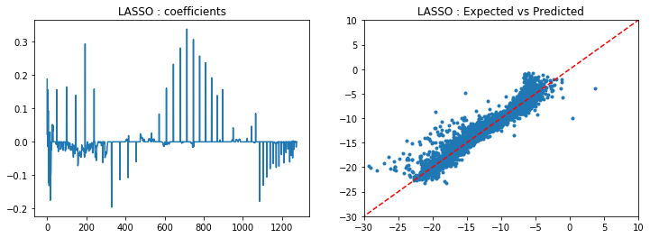

```python
plt.clf
fig, (ax1, ax2) = plt.subplots(1,2)
fig.set_size_inches(12,4)
ax1.plot(wSparse)
ax1.axis('tight')
ax1.set_title('LASSO : coefficients')
ax2.plot(X1.dot(wSparse)+m0,y1+m0,'.')
ax2.plot(np.arange(-100,100),np.arange(-100,100),'r--')
ax2.axis((-30,10,-30,10))
ax2.set_title('LASSO : Expected vs Predicted')
print( 'Lasso: ' + str(E_valid.min()) + '%' )
```

LASSO (24.43%) donne ici de meilleurs résultats que RIDGE (24.92%). De plus, LASSO nous a permis de trouver une solution plus parcimonieuse avec 499 coefficients non nuls, contre 1275 pour RIDGE.

```
Ridge: 1275 non-zero coefficients
Lasso:  499 non-zero coefficients
```

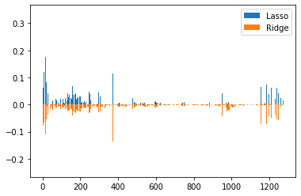

```python
plt.clf
plt.bar(np.arange(1,p+1), abs(wSparse))
plt.bar(np.arange(1,p+1), -abs(wRidge.flatten()))
plt.legend(('Lasso', 'Ridge'))
print('Ridge: ' + str(p-sum(wRidge.flatten()==0)) + ' non-zero coefficients' )
print('Lasso:  ' + str(p-sum(wSparse==0)) + ' non-zero coefficients' )
```

## 2. Classification back to plan

### 2.1. Dataset 2 : Diamonds back to plan

Dans cette étude, nous allons travailler avec le dataset Diamonds de Kaggle. On va s'intéresser à la classe **clarity**. En premier lieu, nous allons faire une classification binaire pour classer les individus dans les catégories prestigieuses **IF, VVS1, VVS2** ou non. Ensuite, nous ferons une classification multiclasse.

```python
kg.api.authenticate()
kg.api.dataset_download_files(dataset="shivam2503/diamonds", path='gt.zip', unzip=True)
df = pd.read_csv('gt.zip/diamonds.csv', encoding='ISO-8859-1')
```

```python
df.head(5)
```

|  | Unnamed: 0 | carat | cut | color | clarity | depth | table | price | x | y | z |
| --- | --- | --- | --- | --- | --- | --- | --- | --- | --- | --- | --- |
| 0 | 1 | 0.23 | Ideal | E | SI2 | 61.5 | 55.0 | 326 | 3.95 | 3.98 | 2.43 |
| 1 | 2 | 0.21 | Premium | E | SI1 | 59.8 | 61.0 | 326 | 3.89 | 3.84 | 2.31 |
| 2 | 3 | 0.23 | Good | E | VS1 | 56.9 | 65.0 | 327 | 4.05 | 4.07 | 2.31 |
| 3 | 4 | 0.29 | Premium | I | VS2 | 62.4 | 58.0 | 334 | 4.20 | 4.23 | 2.63 |
| 4 | 5 | 0.31 | Good | J | SI2 | 63.3 | 58.0 | 335 | 4.34 | 4.35 | 2.75 |

```python
df.describe()
```

|  | Unnamed: 0 | carat | depth | table | price | x | y | z |
| --- | --- | --- | --- | --- | --- | --- | --- | --- |
| count | 53940.000000 | 53940.000000 | 53940.000000 | 53940.000000 | 53940.000000 | 53940.000000 | 53940.000000 | 53940.000000 |
| mean | 26970.500000 | 0.797940 | 61.749405 | 57.457184 | 3932.799722 | 5.731157 | 5.734526 | 3.538734 |
| std | 15571.281097 | 0.474011 | 1.432621 | 2.234491 | 3989.439738 | 1.121761 | 1.142135 | 0.705699 |
| min | 1.000000 | 0.200000 | 43.000000 | 43.000000 | 326.000000 | 0.000000 | 0.000000 | 0.000000 |
| 25% | 13485.750000 | 0.400000 | 61.000000 | 56.000000 | 950.000000 | 4.710000 | 4.720000 | 2.910000 |
| 50% | 26970.500000 | 0.700000 | 61.800000 | 57.000000 | 2401.000000 | 5.700000 | 5.710000 | 3.530000 |
| 75% | 40455.250000 | 1.040000 | 62.500000 | 59.000000 | 5324.250000 | 6.540000 | 6.540000 | 4.040000 |
| max | 53940.000000 | 5.010000 | 79.000000 | 95.000000 | 18823.000000 | 10.740000 | 58.900000 | 31.800000 |

```python
np.unique(df["clarity"])
```

```
array(['I1', 'IF', 'SI1', 'SI2', 'VS1', 'VS2', 'VVS1', 'VVS2'],
      dtype=object)
```

```python
pd.get_dummies(df.clarity, prefix='clarity').columns
```

```
Index(['clarity_I1', 'clarity_IF', 'clarity_SI1', 'clarity_SI2', 'clarity_VS1',
       'clarity_VS2', 'clarity_VVS1', 'clarity_VVS2'],
      dtype='object')
```

```python
# Values
#-----------------------
dfX = pd.concat([df.get(['carat', 'depth','table','price','x','y','z']),
                    pd.get_dummies(df.cut, prefix='cut'),
                    pd.get_dummies(df.color, prefix='color')],
                    axis=1)
X = dfX.values
y_logic = 2*np.float64(np.isin(df.get(['clarity']).values, np.array(['VVS1', 'VVS2', 'IF'])))-1
y_multi = pd.get_dummies(df.clarity, prefix='clarity').values

# Permutation
#-----------------------
np.random.seed(321)
ind = np.random.permutation(X.shape[0])
X = X[ind,:]
y_logic = y_logic[ind,:]
y_multi = y_multi[ind,:]

# Split 50/50
#-----------------------
[n,p] = X.shape
n0 = n*5//10
X0 = X[:n0,:]
y_logic0 = y_logic[:n0,:]
y_multi0 = y_multi[:n0,:]
X1 = X[n0:,:]
y_logic1 = y_logic[n0:,:]
y_multi1 = y_multi[n0:,:]
```

### 2.2. Two Classes Logistic Classification back to plan

On va chercher un modèle de classification binaire, de type régression logistique.  
On normalise les données pour cet exercice, selon les paramètres du dataset d'entrainement.

```python
mX0 = X0.mean(axis=0)
sX0 = X0.std(axis=0)
X0 = (X0-mX0)/sX0
X1 = (X1-mX0)/sX0
y0 = y_logic0
y1 = y_logic1
```

On rajoute une colonne de 1 aux features, pour prendre en compte l'ordonnée à l'origine.

```python
def AddBias(X): return np.hstack(( X, np.ones((np.size(X,0),1)) ))
X0b = AddBias(X0)
X1b = AddBias(X1)
```

On fait une PCA pour observer ce qui se passe. Les classes ne sont pas forcément très bien separées sur les 2 premiers axes.

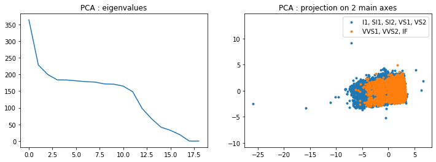

```python
# SVD (for Python, it reads X0=U*diag(s)*V)
#-----------------------
U, s, V = np.linalg.svd(X0)
Xr = X0.dot( V.transpose() )

# Plot eigenvalues + projection
#-----------------------
plt.clf
fig, (ax1, ax2) = plt.subplots(1,2)
fig.set_size_inches(12,4)
ax1.plot(s)
ax1.axis('tight')
ax1.set_title('PCA : eigenvalues')
I0 = np.nonzero(y0==-1)[0]
I1 = np.nonzero(y0==1)[0]
ax2.plot(Xr[I0,0], Xr[I0,1], '.', label= 'I1, SI1, SI2, VS1, VS2')
ax2.plot(Xr[I1,0], Xr[I1,1], '.', label= 'VVS1, VVS2, IF')
ax2.axis('tight')
ax2.axis('equal')
ax2.set_title('PCA : projection on 2 main axes')
ax2.legend();
```

#### 2.2.1. Batch Gradient Descent (BGD) back to plan

On essaye en premier lieu une régression logistique, avec la fonction de perte logistique. Pour cela, on essaye plusieurs valeurs de *gradient step*. Les valeurs qui fonctionnent sont bien supérieures à celle qui assure la convergence.

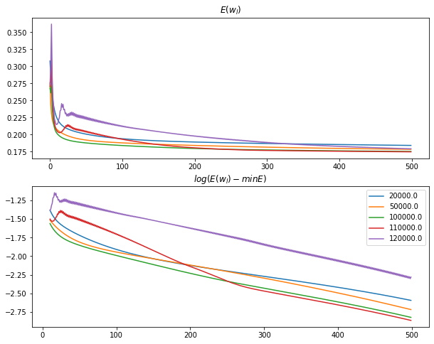

```python
# Fonctions Cout et Gradient
#-----------------------
def L(s,y):  return 1/n * sum( np.log( 1 + np.exp(-s*y) ) )
def E(w,X,y): return L(X.dot(w),y)
def theta(v): return 1 / (1+np.exp(-v))
def nablaL(s,y): return - 1/n * y * theta(-s * y)
def nablaE(w,X,y): return X.transpose().dot( nablaL(X.dot(w),y) )

# Initialization
#-----------------------
niter = 750
ndisp = niter*2//3
tau_max = 2/(1/4 * np.linalg.norm(AddBias(X0), 2)**2 )
tau_mult = [2e4, 5e4, 10e4, 11e4, 12e4]
plt.clf
fig, (ax1, ax2) = plt.subplots(2, 1)
fig.set_size_inches(10,8)

# Gradient Step benchmark
#-----------------------
for itau in np.arange(0,len(tau_mult)):
    tau = tau_max*tau_mult[itau]
    Elist = np.zeros([niter,1])
    w = np.zeros((p+1,1))
    for i in np.arange(0,niter):
        w = w - tau * nablaE(w,X0b,y0)
        Elist[i] = E(w,X0b,y0)
    ax1.plot(Elist[0:ndisp])
    ax1.axis('tight')
    ax1.set_title('$E(w_l)$')
    ax2.plot(np.arange(10,ndisp), np.log10(Elist[10:ndisp]-np.min(Elist)+1e-20) ,label=str(tau_mult[itau]))
    ax2.axis('tight')
    ax2.set_title('$log(E(w_l) - min E)$');
    ax2.legend();
```

Les performances avec $\tau = 110000 \times \tau_{max}$ semblent légerement meilleures, mais la convergence semble moins stable.  
On retient finalement la valeur $\tau = 100000 \times \tau_{max}$, on fait plus d'itérations et on vérifie que l'on ne fait pas d'overfitting.

```python
# Descente de gradient
#-----------------------
niter = 3000
ndisp = niter
tau = tau_max*10e4
Elist = np.zeros([niter,1])
Vlist = np.zeros([niter,1])
w = np.zeros((p+1,1))
for i in np.arange(0,niter):
    #if i%250==0 : print(str(i))
    w = w - tau * nablaE(w,X0b,y0)
    Elist[i] = E(w,X0b,y0)
    Vlist[i] = E(w,X1b,y1)
wBatch = w
```

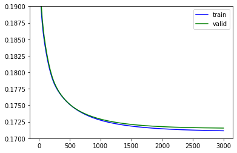

```python
# Affichage évolution train/test
#-----------------------
plt.clf
plt.plot(Elist[0:ndisp],'b',label = 'train')
plt.plot(Vlist[0:ndisp],'g',label = 'valid')
plt.ylim([0.17,0.19])
plt.legend();
```

##### 2.2.3.2. Stochastic Gradient Descent (SGD) back to plan

Pour accélerer la convergence, on met en place une descente de gradient stochastique. Au lieu de considerer l'ensemble des individus à chaque itération, on n'en tire qu'un au hasard, en considérant que la direction descente résultante sur l'ensemble des itérations va statistiquement se rapprocher de celle correspondant à l'ensemble des individus.

```python
# Fonctions Cout et Gradient
#-----------------------
def MakeCol(y): return y.reshape(-1,1)
def nablaEi(w,X,y,i): return MakeCol( -y[i] * X[i,:].transpose() * theta( -y[i] * (X[i,:].dot(w)) ) )

# Parametres
#-----------------------
niter = 500000
err_rate = 2500 # on ne loggue qu'une valeur sur 2500
l0_arr = [100, 1000, 10000]
l0_par = ['-','--','-.']
tau0_arr = [.05,.1,.5,1]
tau0_par = ['c','b','g','r']

# Evaluation en fonction des hyperparametres
#-----------------------
ElistS = np.zeros(( int(niter/err_rate), len(l0_arr)*len(tau0_arr)))
WlistS = np.zeros(( p+1, len(l0_arr)*len(tau0_arr)))
irun = 0
for il0 in range(len(l0_arr)):
    for itau0 in range(len(tau0_arr)):
        l0 = l0_arr[il0]
        tau0 = tau0_arr[itau0]
        w = np.zeros((p+1,1))
        for it in np.arange(0,niter):
            if np.mod(it,   err_rate)==1: ElistS[int(it/err_rate),irun] = E(w,X0b,y0)
            #if np.mod(it,40*err_rate)==1: print(str(it))
            tau = tau0 / (1+it/l0)
            i = int(np.floor(np.random.rand()*n0))# draw uniformly
            w = w - tau * nablaEi(w,X0b,y0,i)
        WlistS[:,irun]+=w.flatten()
        irun+=1
```

En observant l'évolution des performances en fonction des paramètres, on voit qu'un faible *l0* (décroissance rapide du gradient step) couplée à un un fort $\tau_{0} = 1$ permet de converger rapidement vers une performance comparable à celle du *Batch Gradient Descent (BGD)*. Mais pour une meilleure performance, on préfère $\tau_{0} = 1$ et $l_{0} = 1000$.

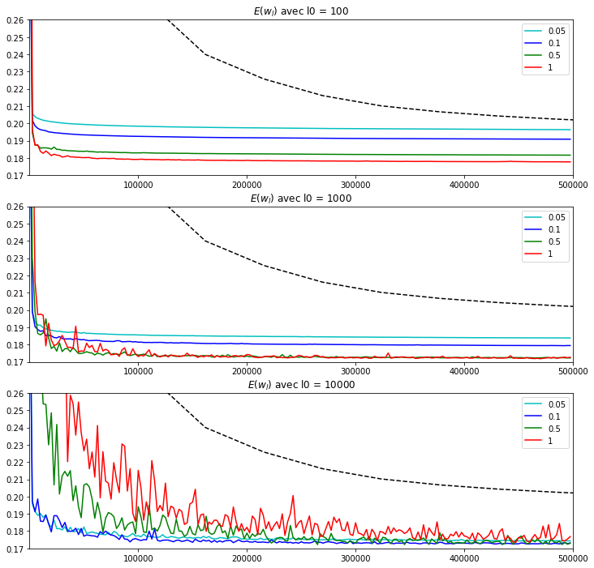

```python
plt.clf
fig, AX = plt.subplots(3, 1)
fig.set_size_inches(12,12)
vmin = np.min(Elist)
irun = 0
for il0 in range(len(l0_arr)):
    for itau0 in range(len(tau0_arr)):
        AX[il0].plot(np.arange(0,niter,err_rate),ElistS[:,irun], tau0_par[itau0], label = tau0_arr[itau0])
        irun+=1
    AX[il0].plot(1+np.arange(0, Elist.size)*n, Elist , 'k--')
    AX[il0].set_title('$E(w_l)$ avec l0 = ' + str(l0_arr[il0]))
    AX[il0].axis((1,niter, .17, .26))
    AX[il0].legend();
wStochastic = WlistS[:,7]
```

##### 2.2.3. Comparaison des performances back to plan

On veut s'assurer que malgré des temps de calculs vraiment différents, les 2 modèles ont des performances équivalentes.  
On regarde les matrices de confusion.  
- remarques : nos données sont déséquilibrées  
- globalement, on est sur des niveaux de performance très proches.

```python
from sklearn.metrics import confusion_matrix
def plot_confusion(cm,titre):
    plt.imshow(cm, interpolation='nearest', cmap=plt.cm.binary)
    plt.title(titre)
    plt.set_cmap('Blues')
    plt.colorbar()
    target_names = ['VVS1, VVS2, IF', 'others']
    tick_marks = np.arange(len(target_names))
    plt.xticks(tick_marks, target_names, rotation=60)
    plt.yticks(tick_marks, target_names)
    plt.ylabel('True label')
    plt.xlabel('Predicted label')
    plt.text(0,0,str(cm[0,0]), horizontalalignment='center', bbox=dict(facecolor='white', alpha=0.5))
    plt.text(0,1,str(cm[0,1]), horizontalalignment='center', bbox=dict(facecolor='white', alpha=0.5))
    plt.text(1,0,str(cm[1,0]), horizontalalignment='center', bbox=dict(facecolor='white', alpha=0.5))
    plt.text(1,1,str(cm[1,1]), horizontalalignment='center', bbox=dict(facecolor='white', alpha=0.5))
    plt.tight_layout()
```

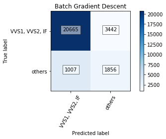

```python
plot_confusion(confusion_matrix(y1,2*np.round(theta(X1b.dot(wBatch)))-1),'Batch Gradient Descent')
```

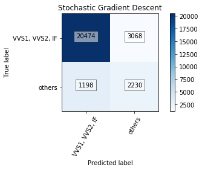

```python
plot_confusion(confusion_matrix(y1,2*np.round(theta(X1b.dot(wStochastic)))-1),'Stochastic Gradient Descent')
```

Les performances sont également très proches pour les métriques ROC et AUC, comme le montre la figure ci-dessous.  
En effet, les courbes sont superposées.

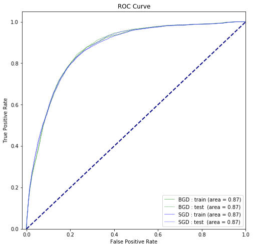

```python
# Calcul des AUC et courbes ROC
#-----------------------
from sklearn.metrics import roc_curve, auc
fpr_BGD_0, tpr_BGD_0, _ = roc_curve(y0, theta(X0b.dot(wBatch)))
fpr_BGD_1, tpr_BGD_1, _ = roc_curve(y1, theta(X1b.dot(wBatch)))
roc_auc_BGD_0 = auc(fpr_BGD_0, tpr_BGD_0)
roc_auc_BGD_1 = auc(fpr_BGD_1, tpr_BGD_1)
fpr_SGD_0, tpr_SGD_0, _ = roc_curve(y0, theta(X0b.dot(wStochastic)))
fpr_SGD_1, tpr_SGD_1, _ = roc_curve(y1, theta(X1b.dot(wStochastic)))
roc_auc_SGD_0 = auc(fpr_SGD_0, tpr_SGD_0)
roc_auc_SGD_1 = auc(fpr_SGD_1, tpr_SGD_1)

# Affichage
#-----------------------
fig = plt.figure()
fig.set_size_inches(8,8)
plt.plot(fpr_BGD_0, tpr_BGD_0,'g'  , lw=.5, label='BGD : train (area = %0.2f)' % roc_auc_BGD_0)
plt.plot(fpr_BGD_1, tpr_BGD_1,'g--', lw=.5, label='BGD : test  (area = %0.2f)' % roc_auc_BGD_1)
plt.plot(fpr_SGD_0, tpr_SGD_0,'b'  , lw=.5, label='SGD : train (area = %0.2f)' % roc_auc_SGD_0)
plt.plot(fpr_SGD_1, tpr_SGD_1,'b--', lw=.5, label='SGD : test  (area = %0.2f)' % roc_auc_SGD_1)
plt.plot([0, 1], [0, 1], color='navy' , lw=2, linestyle='--')
plt.xlim([-0.02, 1.0])
plt.ylim([0.0, 1.05])
plt.xlabel('False Positive Rate')
plt.ylabel('True Positive Rate')
plt.title('ROC Curve')
plt.legend(loc="lower right")
plt.show()
```

### 2.3. Multi-Classes Logistic Classification back to plan

Nous nous essayons alors à un execice de classification multiple, sur l'ensemble des modalités de la feature **clarity**.  
Mais les performances ne sont pas au rendez-vous. Ce type de classification ne semble pas convenir.  
**Ou sinon, peut-être ai-je manqué quelque chose, mais je ne vois pas ...?**

La descente de gradient ne converge pas vers une limite très satisfaisante.

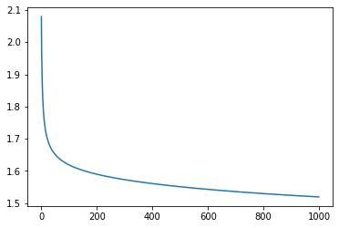

```python
# Target Data
#-----------------------
y0 = y_multi0
y1 = y_multi1

# Fonctions Cout et Gradient
#-----------------------
def LSE0(S): return np.log( np.exp(S).sum(axis=1,keepdims=1))
def max2(S): return np.tile( S.max(axis=1,keepdims=1), (1,S.shape[1]) )
def LSE(S): return LSE0( S-max2(S) ) + S.max(axis=1,keepdims=1)
def SM0(S): return np.exp(S) / np.tile( np.exp(S).sum(axis=1,keepdims=1), (1, S.shape[1]) );
def SM(S): return SM0(S-max2(S))
def dotp(x,y): return x.flatten().dot( y.flatten().transpose() )
def E(n,X,W,D): return 1/n*( LSE(X.dot(W)).sum() - dotp(X.dot(W),D)  )
def nablaE(n,X,W,D): return 1/n * X.transpose().dot( SM(X.dot(W)) -  D  )

# Descente de gradient
#-----------------------
niter = 1000
step = 50
W = np.zeros((p+1,y0.shape[1]))
Elist = np.zeros((niter,1))
tau = 1
for i in np.arange(0,niter):
    #if i%step==0 : print(str(i))
    Elist[i] = E(n-n0,X1b,W,y1)
    W = W - tau * nablaE(n0,X0b,W,y0)
plt.clf
plt.plot(Elist)
plt.axis('tight');
```

La matrice de confusion est complètement dans les choux.

```python
y_true = np.argmax(y1,axis=1)
y_pred = np.argmin(SM(-X1b.dot(W)),axis=1)
confusion_matrix(y_true, y_pred)
```

```
array([[  35,    0,   47,  269,    0,   12,    0,    1],
       [   0,   14,   13,    0,  254,  239,  245,  127],
       [   0,   10, 3442, 1060,  279, 1575,  136,   47],
       [   1,    3, 1300, 2733,   55,  485,   22,   17],
       [   0,   13, 1022,   36,  603, 2015,  241,  144],
       [   0,    8, 2222,  120,  489, 2864,  229,  137],
       [   0,   15,   96,    0,  403,  822,  305,  178],
       [   0,   12,  222,    2,  564, 1328,  248,  211]])
```